# Erneuerbare Energie und wirtschaftl. Wachstum - eine Untersuchung auf deren Zusammenhang

Gruppe 78

12.02.2022

### 1. Einleitung

Der globale Klimawandel stellt die Menschheit vor eine der größten Herausforderungen des 21. Jahrhunderts. Wie man ein Gleichgewicht zwischen nachhaltiger sozioökonomischer Entwicklung und Klimaschutz schafft, ist zu einem zentralen Thema der Diskussion geworden. Als der Schlüssel zur Lösung der ganzen Problematiken gewinnen die erneuerbaren Energien daher in den vergangenen Jahrzehnten enorm an Bedeutung. Wie ist aber der aktuelle Stand der Sache?

In diesem Projekt möchten wir mithilfe quantitativer Datenanalysen die Tendenzen im globalen Energieverbrauch untersuchen, und dabei insbesondere auf die Fragestellung eingehen, ob ein **Zusammenhang zwischen der Nutzung nachhaltiger Energiequellen und dem Entwicklungsstand eines Landes** besteht.

Dafür haben wir einen Datensatz aus Our World in Data (OWID) herangezogen. OWID ist eine wissenschaftliche Online-Publikation, die sich auf große globale Probleme wie Armut, Krankheit, Hunger, Klimawandel, Krieg, existenzielle Risiken und Ungleichheit konzentriert. Das Forschungsteam ist an der University of Oxford angesiedelt.

Die Daten werden wiederum aus einer Kombination von diversen Quellen erhoben, darunter: BP Statistical Review of World Energy, SHIFT Data Portal, EMBER – Global Electricity Dashboard, sowie die Vereinten Nationen und Weltbank.

Der Datensatz enthält Informationen zum Energieverbrauch (Primärenergie, Pro-Kopf- und Wachstumsraten), Energiezusammensetzung, Stromzusammensetzung und andere relevante Kennzahlen der letzten Jahrzehnte von rund 200 Staaten. Hinzu kommen noch länderspezifische Daten wie (reales) BIP und Population. Somit sind alle Typen von Variablen (kategorische, diskret numerische und kontinuierlich numerische) enthalten.

### 2. Explorative Datenanalyse

Wir initialisieren zuerst unsere Daten:

```r
library("tidyverse")
library("cowplot")    # um mehrere Plots anzuordnen
library("weights")    # für den gewichteten Korrelationskoeffizient; wird später benötigt
```

```r
energycsp <- read_csv(file.path("data", "World_Energy_Consumption.csv"))
```

```r
# Bei unserem Datensatz gibt es auch Kontinente bzw. "World" als "country". Deswegen werden alle
# "Ländernamen", die kein Land bezeichnen, separat in einer txt-Datei abgespeichert, hier lesen wir sie ab.
non_countries <- scan(file.path("data", "World_Energy_Cons_Non_Countries.txt"), character(), sep = "\n")
```

Zunächst interessieren wir uns für die Entwicklung der Stromerzeugung durch traditionelle Energiequellen, beispielsweise Kohle, in den letzten 35 Jahren.

```r
p1 <- energycsp %>%
  filter(country %in% c("Africa","Asia Pacific","Europe","North America","Middle East","South & Central America"),
         year %in% 1985:2019) %>%                                # Auswählen der Daten
  ggplot(aes(x = year, y = coal_share_elec, color = country)) +  # Plot initialisieren
  geom_line(size = 1.5) +                                        # Punkte zum Darstellen der Daten verwenden
  labs(y = "Anteil Kohlestrom in %", x = "Jahr") +
  theme_bw()
```

```r
p2 <- energycsp %>%
  filter(country == "World", year %in% 1985:2019) %>%
  ggplot(aes(x = year)) +
  geom_line(size = 1.5, aes(y = coal_share_elec), color = "orangered3") +
  geom_line(size = 1.5, aes(y = renewables_share_elec), color = "limegreen") +
  scale_y_continuous(
    name = "Anteil Kohlenstrom in %",
    sec.axis = sec_axis(~., name = "Anteil erneuerbares Stroms in %")) +  # zweite y-Achse rechts
  theme_bw() +
  theme(
    axis.title.y = element_text(color = "orangered3"),
    axis.title.y.right = element_text(color = "limegreen"))      # Ändere Farben der Achsentiteln
```

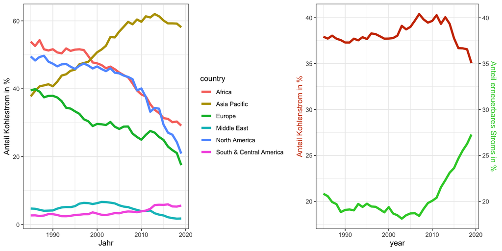

```r
plot_grid(p1, p2, rel_widths = c(1.4, 1))                        # Ordne Plots an
```

Nun schauen wir uns die Wachstumsendenzen der verschieden Energiearten an.

Um redundanten Code zu vermeiden, schreiben wir eigene Funktionen für alle ähnlichen Plots (diese hier ist für die Plots der prozentualen Änderungen, also für die unten in der 2. Zeile):

```r
# Die Funktion nimmt einen bearbeiteten Datensatz und eine sortierte Liste gewünschter Spalten als Argumente an
plot_energies <- function(dataframe, chosen_rows) {
  df <- dataframe %>%
    # Wähle alle übergebenen Spalten des übergebenen Datensatzes aus
    select(year, all_of(chosen_rows)) %>%
    # Überschreibe alle numerischen NA-Werte mit 0
    mutate(across(where(is.numeric), replace_na, 0)) %>%
    # Ergänze den fehlenden prozentualen Anteil durch eine neue Größe "rest_share"
    mutate(rest_share = 100 - rowSums(select(., -year))) %>%
    # Vermeide dadurch enstandene, unerwünschte Restsäulen wegen fehlenden Daten
    mutate(rest_share = ifelse(rest_share >= 6, 0, rest_share)) %>%
    # Umwandle vom Wide-Format zum Long-Format fürs Plotten; "pivot_longer" ist die neuere Version von "gather()"
    pivot_longer(cols = -year, names_to = "energy_type", values_to = "percentage")

  # Ordne "energy_type" in der gewünschten Reihenfolge an; hier wird die als Funktionsargument übergebene,
  # vorsortierte Liste "chosen_rows" um die neuberechnete Restspalte ergänzt
  df$energy_type <- factor(df$energy_type, levels = c(chosen_rows, "rest_share"))

  df %>%
    # "fill =" bestimmt die Füllfarbe der Säulen, "color =" bestimmt die Randfarbe
    ggplot(aes(x = year, y = percentage, fill = energy_type)) +
    geom_bar(stat = "identity", width = 1, color = "white", size = 0.08) +
    labs(x = "Jahr", y = "Anteil in %", fill = NULL) +
    # Die Listen "labels" und "colors" wurden schon vorab definiert
    scale_fill_manual(labels = labels, values = colors) +
    scale_x_continuous(breaks = seq(1985, 2020, by = 5), expand = c(0, 0.2, 0, 0.2)) +
    scale_y_continuous(breaks = seq(0, 100, by = 20), expand = c(0, 0, 0, 0.5)) +
    theme_half_open(10) +
    theme(plot.margin = margin(6, 10, 6, 0), plot.title = element_text(hjust = 0.5))
}
```

```r
plot_energies_2 <- function(dataframe, chosen_rows) {
  df <- dataframe %>%
    select(year, all_of(chosen_rows)) %>%
    mutate(across(where(is.numeric), replace_na, 0)) %>%
    # Dividiere die Anzahl Kilowattstunden durch 1000, damit es nicht zu viele Nullen an den Achsen stehen
    mutate(across(-year, function(x) x/1000))

  # Im Datensatz gibt es Statistiken für "andere erneuerbare Energien", die die Statistiken für "Biokraftstoff"
  # aber schon beinhalten, also substrahieren wir diese davon ab. Damit wir den gleichen Code nicht zweimal
  # schreiben müssen, substrahieren wir hier allgemein die Daten der letzten Spalte durch die der vorletzten
  # Spalte, anstatt mithilfe der Spaltennamen.
  df[ncol(df)] <- df[ncol(df)] - df[ncol(df)-1]

  df <- df %>%
    pivot_longer(cols = -year, names_to = "energy_type", values_to = "total")
  df$energy_type <- factor(df$energy_type, levels = chosen_rows)

  df %>%
    ggplot(aes(x = year, y = total, fill = energy_type)) +
    geom_area(stat = "identity", color = "white", size = 0.08) +
    labs(x = NULL, y = expression(paste("[", 10^9, " kWh]")), fill = NULL) +
    scale_fill_manual(labels = labels, values = colors) +
    scale_x_continuous(breaks = seq(1985, 2020, by = 5), expand = c(0, 0.7, 0, 0.7)) +
    theme_half_open(10) +
    theme(plot.margin = margin(6, 10, 6, 0), plot.title = element_text(hjust = 0.5))
}
```

Zuerst kommen die Daten für die ganze Welt:

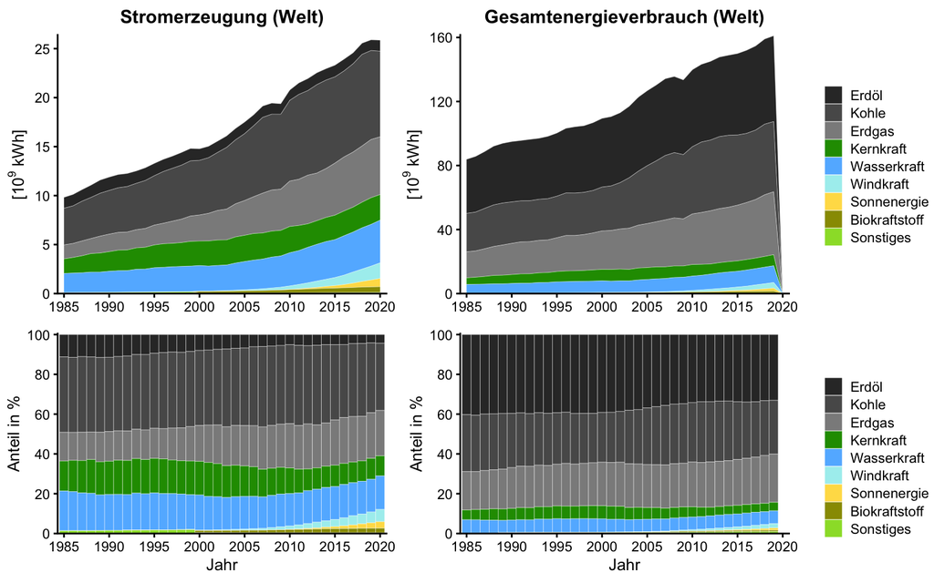

```r
world_energy <- filter(energycsp, country == "World", year %in% 1985:2020)

# Wir benutzen die oben definierte Funktion "plot_energies()" zweimal, mit verschiedenen Parametern.
# "sorted_share_elec" und "sorted_share_energy" sind jeweils die vorab definierten sotierten Listen der # Spaltennamen, die wir nun als Parameter in unsere Funktion einsetzen.
p3 <- plot_energies(world_energy, sorted_share_elec)
p4 <- plot_energies(world_energy, sorted_share_energy)

# "plot_energies_2()" ist die Funktion für die zwei Plots in der oberen Zeile
p1 <- plot_energies_2(world_energy, sorted_electricity) +
  scale_y_continuous(breaks = seq(0, 25, by = 5), expand = c(0, 0, 0, 0.5)) +
  labs(title = "Stromerzeugung (Welt)")
p2 <- plot_energies_2(world_energy, sorted_consumption) +
  scale_y_continuous(breaks = seq(0, 160, by = 40), expand = c(0, 0, 0, 0.5)) +
  labs(title = "Gesamtenergieverbrauch (Welt)")

# Speichere vorerst die Legende von "p1" als ein Plot-Objekt ab, damit das Resultat schöner aussieht...
legend <- get_legend(
  p1 + theme(legend.box.margin = margin(0, 0, 0, 12)))

# Dies leistet das Äquivalente wie "grid.arrange()" im Paket "gridExtra"
plot_grid(
  # Folgende Plot-Objekte (also auch zweimal die Legende) ordnen wir an:
  p1 + theme(legend.position = "none"), p2 + theme(legend.position = "none"), legend,
  p3 + theme(legend.position = "none"), p4 + theme(legend.position = "none"), legend,
  align = 'vh',        # Richte die Plots vertikal und horizontal aus
  axis = 'l',          # und zwar so, dass die vertikale Achsen der Plots aufeinander ausgerichtet sind
  nrow = 2, ncol = 3,  # Die Plots sollen in 2 Zeilen und 3 Spalten angeordnet werden
  rel_widths = c(5, 5, 1.6), rel_heights = c(0.5, 0.4, 0)
                       # Ändere die relativen Breiten bzw. Höhen der jeweiligen Zeile und Spalte
)
```

Wir beobachten ein globales Wachstum der Nutzung erneuerbarer Energien (sowohl prozentual als auch insgesamt): ein schneller Zuwachs an Wind- und Solarenergie ist deutlich erkennbar.

Allerdings sieht man, dass fossile Brennstoffe wegen Kraftfahrzeugen, Gasherden usw. immer noch eine überwiegende Bedeutung haben, insbesondere betragen sie seit 1985 einen beinahe unveränderten Anteil von ca. 85% des gesamten Energieverbrauchs der Welt, welcher sich in dieser Zeit fast verdoppelt hat.

Beim Jahr 2008/09 erkennt man einen kleinen Einschnitt in den oberen Graphen - wohl aufgrund der globalen Wirtschaftskrise.

Jetzt schauen wir ein paar spezifische Länder an:

```r
library("countrycode")    # um englische Ländernamen zu übersetzen
translate <- function(country_name) {
  countrycode(country_name, origin = 'country.name', destination = 'country.name.de')
}
```

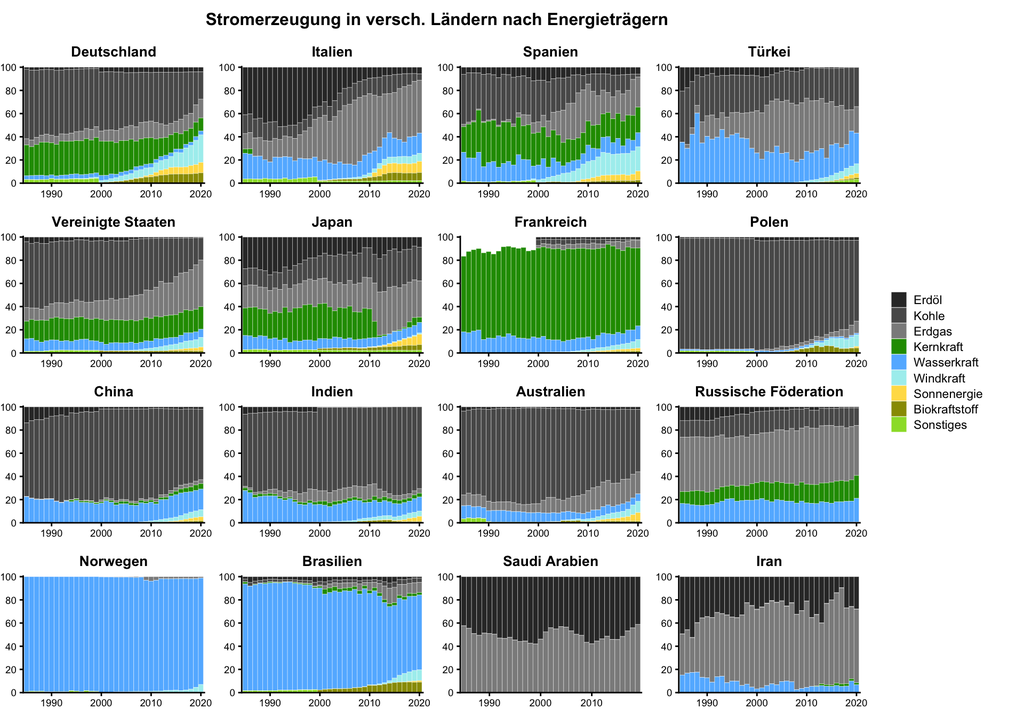

```r
sample_countries <- c("Germany","Italy","Spain","Turkey",     "United States","Japan","France","Poland",
                      "China","India","Australia","Russia",   "Norway","Brazil","Saudi Arabia","Iran")

# Die Funktion "lapply()" leistet das Gleiche wie Broadcasting in Julia: sie nimmt eine Liste als erstes # Argument an, wendet auf jedes Element die als zweites Argument übergebene Funktion an, und gibt die daraus
# resultierende neue Liste zurück. Hier bekommen wir damit eine 16-elementige Liste von Plots.
plots <- sample_countries %>% lapply(function(chosen_country) {
  energycsp %>%
    filter(country == chosen_country, year %in% 1985:2020) %>%
    plot_energies(sorted_share_elec) +
    scale_x_continuous(breaks = seq(1990, 2020, by = 10), expand = c(0, 0.2, 0, 0.2)) +
    labs(title = translate(chosen_country), x = NULL, y = NULL) +
    theme(legend.position = "none",
          plot.title = element_text(size = 10), axis.text = element_text(size = 7))
  })
# Speichere den Haupttitel auch als ein Plot-Objekt ab...
title <- ggdraw() + draw_label("Stromerzeugung in versch. Ländern nach Energieträgern",
                               fontface = 'bold', size = 12)

# Hole eins nach dem anderen alle Elemente von "plots" und danach das Argument "ncol = 4", und wende darauf die
# Funktion "plot_grid()" an
do.call(plot_grid, c(plots, ncol = 4)) %>%
  # Füge den Titel oben und dann die Legende rechts hinzu; der Pipe-Operator "%>%" ersetzt alle Vorkommnissen
  # von "." mit dem gepipeten Argument
  plot_grid(title, ., ncol = 1, rel_heights = c(1, 18)) %>%
  plot_grid(legend, nrow = 1, rel_widths = c(7, 1.2))
```

Die Anteile verschiedener Energieträger an Stromerzeugung können also bei verschieden Ländern sehr unterschiedlich ausschauen.

In Frankreich stammen mehr als 60% des Stroms aus Kernkraftwerken, hingegen wird in Japan aufgrund der Fukushima-Katastrophe 2011 kaum noch Atomstrom produziert; während große Ölproduzenten ohne große Reliefunterschiede (wie Saudi-Arabien und Iran) ihr eigenes Erdöl und Erdgas zur Krafterzeugung bevorzugen, können Länder wie Brasilien und Norwegen dank geographischen Verhältnissen den Großteil ihres Stroms aus Wasserkraft gewinnen. Außerdem kann man bei trockeneren Ländern (z.B. Spanien, Türkei) größere jährliche Schwankungen der Wasserkraft erkennen.

Eines haben die meisten Länder aber gemeinsam: man sieht einen schnellen Zuwachs an neuartigen Energien (v.a. Wind-, Solar- und Biomassestrom) in den letzten Jahren, was wir zuvor schon bei der Weltstatistik beobachtet haben. In Deutschland ist insbesondere der Anteil an erneuerbarem Strom von weniger als 10% im Jahr 2000 auf fast die Hälfte im Jahr 2020 gestiegen.

### 3. Methoden

#### Der empirische Korrelationskoeffizient

Ein positiver Korrelationskoeffizient, der betragsmäßig kleiner als 1 ist, deutet eine postive Steigung der Regressionsgerade an. Dies gerechtfertigt unser weiteres Vorgehen mit Verwendung eines linearen Regressionsmodells.

#### Gewichtete lineare Regression

Da die Länder verschiedene Bevölkerungsanzahl haben (China 1,400,000,000 vs. Liechtenstein 38,000), liegt es nahe, eine *gewichtete lineare Regression* anzuwenden.

Zuerst führen wir den gewichteten empirischen Mittelwert und die gewichtete empirische Varianz bzw. Kovarianz ein, wobei $w_i\geq0$ jeweils den Gewichtungsfaktor bezeichnet (hier: $w_i=$ Bevölkerungsanzahl; ungewichteter Fall: $w_i=1$ für alle $i=1,\ldots,n$):

Zu minimieren ist $Q(\alpha, \beta) = \sum_{i=1}^n w_ir_i^2$, wobei Residuum $r_i = y_i-(\beta x_i + \alpha)$:

Man rechnet wie in der Vorlesung nach, dass für die Minimumstelle von $Q$ Folgendes gilt:

$$r_{x,y} = \frac{s_{x,y}}{\sqrt{s_x^2 s_y^2}}$$

#### Literatur:

- Das Vorlesungskript
- https://www.itl.nist.gov/div898/handbook/pmd/section1/pmd143.htm
- https://www.itl.nist.gov/div898/handbook/pmd/section4/pmd432.htm

### 4. Ergebnisse und Schlussfolgerungen

Wir wollen uns auf unsere am Anfang gestellte Frage eingehen, also ob es einen Zusammenhang zwischen dem Zuwachs erneuerbarer Energien und dem Wohlstand eines Landes gibt. Zuerst wollen wir aber herausfinden, ob der **gesamte Energieverbrauch** überhaupt etwas mit dem **Wohlstand eines Landes** zu tun hat.

Auch hier schreiben wir eine **Funktion für alle Plots** der gewichteten linearen Regression nach der Bevölkerung eines Landes, die empirischen Korrelationskoeffizienten von beiden Variablen befinden sich jeweils am Titel des Plots:

```r
# Ändere "per_capita_electricity" zu "elec_per_capita" für mehr Konsistenz
names(energycsp)[names(energycsp) == "per_capita_electricity"] <- "elec_per_capita"

nan_inf_to_na <- function(value)
  ifelse(is.finite(value), value, NA)

df <- energycsp %>%
  filter(year %in% c(2015, 2016), !(country %in% non_countries)) %>%
  mutate(gdp_per_capita = gdp / population) %>%
  mutate(gdp_per_capita_increase = (gdp_per_capita / lag(gdp_per_capita) - 1) * 100) %>%
  mutate(renewables_elec_increase = (renewables_electricity / lag(renewables_electricity) - 1) * 100) %>%
  mutate(across(c(gdp_per_capita_increase, renewables_elec_increase), nan_inf_to_na)) %>%
  filter(year == 2016)

plot_regression <- function(var_y, var_x = "gdp_per_capita", biggest = 0, smallest = 0) {
  df_new <- df %>%
    select(year, country, population, all_of(var_x), all_of(var_y)) %>%
    # Filtere alle Zeilen raus, die NA-Werte beinhalten
    drop_na()

  lm <- df_new %>%
    lm(formula = get(var_y) ~ get(var_x), data = ., weight = population)

  df_new %>%
    # Speichere die Residuen des linearen Modells als neue Spalte des Datensatzes ab
    mutate(resid = residuals(lm)) %>%
    arrange(resid) %>%
    ggplot(aes(x = get(var_x))) +
    geom_point(aes(y = get(var_y), size = population),
               color = "black", alpha = 0.6) +
    geom_smooth(aes(y = get(var_y), weight = population),
                method = 'lm', formula = y ~ x) +
    # Filtere diejenige Zeilen der größten bzw. kleinsten Werten von "resid_energy" raus, und plotte nochmal
    # mit Farbe auf den alten Plot drauf; "str_wrap()" schreibt lange Ländernamen (hier: mehr als 5 Zeichen,
    # und falls möglich) in mehreren Zeilen um
    geom_point(data = . %>% tail(biggest),
               aes(y = get(var_y), size = population, color = str_wrap(translate(country), 5))) +
    geom_point(data = . %>% head(smallest),
               aes(y = get(var_y), size = population, color = str_wrap(translate(country), 5))) +
    scale_color_brewer(palette="Set1") +
    labs(x = "BIP pro Kopf (inflationsbereinigt) [USD]", color = NULL,
         title = paste("empr. Korrelationskoeff. = ",
                       # sqrt(summary(lm)$r.squared) %>% {format(round(., 5), nsmall = 5)})) +
                       wtd.cor(df_new[var_x], df_new[var_y], df_new$population) %>%
                         {format(round(., 5), nsmall = 5)})) +
    guides(size = "none") +
    theme_classic() +
    theme(plot.title = element_text(size = 10),
          axis.title = element_text(size = 10), axis.text = element_text(size = 8),
          plot.margin = unit(c(0.5,1,0.5,1), "lines"))
}
```

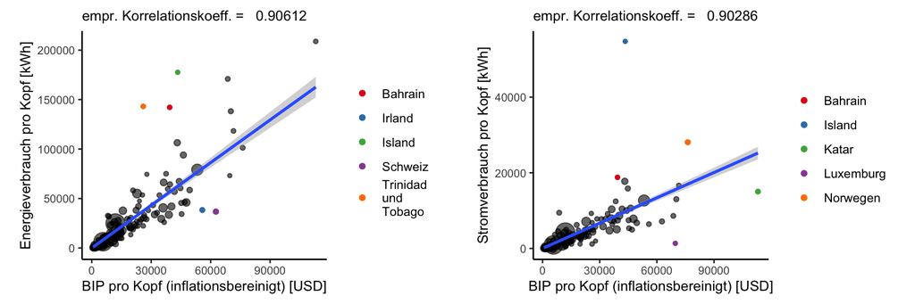

```r
plot_grid(
  plot_regression("energy_per_capita", biggest = 3, smallest = 2) +
    labs(y = "Energieverbrauch pro Kopf [kWh]"),
  plot_regression("elec_per_capita", biggest = 3, smallest = 2) +
    labs(y = "Stromverbrauch pro Kopf [kWh]")
)
```

Wie erwartet sehen wir fürs Jahr 2016 einen schönen, näherungsweise **linearen Zusammenhang** zwischen BIP und Energie- sowie Stromverbrauch pro Kopf. In einfachen Worten: je mehr Geld man zur Verfügung hat, desto mehr Energie verbraucht man.

Ausnahmen dazu (mit großen Residuen zur Regressionsgerade) sind Inselstaaten, die entweder Steueroasen oder stark von der Industrie geprägt sind, sowie einige wohlhabende Länder in den Norden, die viel Energie zur Heizung etc. verbrauchen.

Aber: wie sieht’s aus für die Nutzung bzw. das Wachstum **erneuerbarer Energien** im Verhältnis zum **BIP** aus?

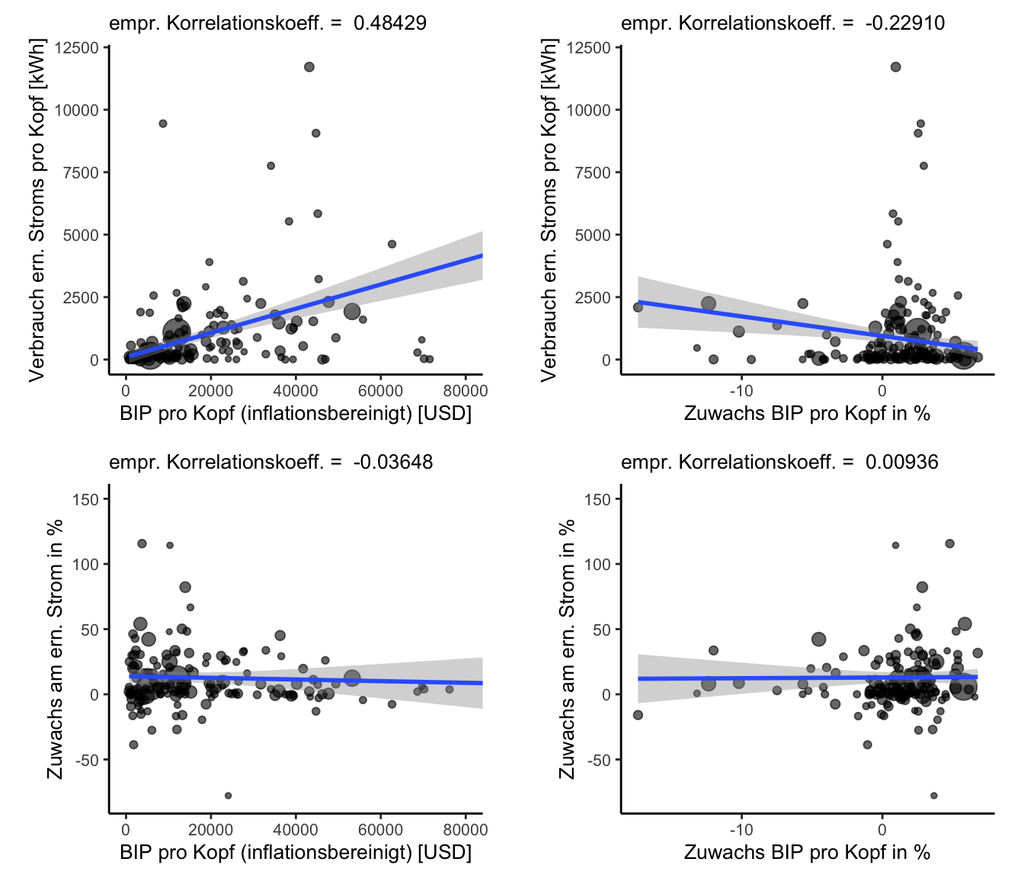

```r
plot_grid(
  plot_regression("renewables_elec_per_capita") +
    labs(y = "Verbrauch ern. Stroms pro Kopf [kWh]")
  + coord_cartesian(ylim = c(0, 12000), xlim = c(0, 80000))
  ,
  plot_regression("renewables_elec_per_capita", "gdp_per_capita_increase") +
    labs(y = "Verbrauch ern. Stroms pro Kopf [kWh]", x = "Zuwachs BIP pro Kopf in %")
  + coord_cartesian(ylim = c(0, 12000))
  ,
  plot_regression("renewables_elec_increase") +
    labs(y = "Zuwachs am ern. Strom in %")
  + coord_cartesian(ylim = c(-80, 150), xlim = c(0, 80000))
  ,
  plot_regression("renewables_elec_increase", "gdp_per_capita_increase") +
    labs(y = "Zuwachs am ern. Strom in %", x = "Zuwachs BIP pro Kopf in %")
  + coord_cartesian(ylim = c(-80, 150))
  ,
  align = 'vh', axis = 'l'
)
```